# Problem 1:Linear Regression

You are hired by a company Gem Stones co ltd, which is a cubic zirconia manufacturer. You are provided with the dataset containing the prices and other attributes of almost 27,000 cubic zirconia (which is an inexpensive diamond alternative with many of the same qualities as a diamond). The company is earning different profits on different prize slots. You have to help the company in predicting the price for the stone on the bases of the details given in the dataset so it can distinguish between higher profitable stones and lower profitable stones so as to have better profit share. Also, provide them with the best 5 attributes that are most important.

## Data Description:

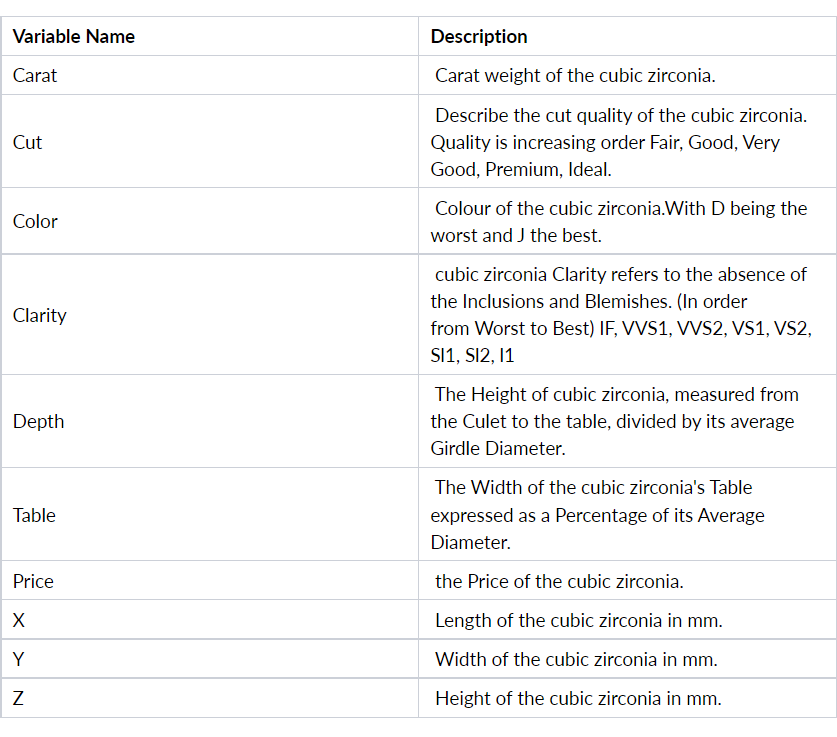

## Importing required packages:

```python
import numpy as np
import pandas as pd
import matplotlib.pyplot as plt
%matplotlib inline
import seaborn as sns
from sklearn.preprocessing import StandardScaler
from sklearn.model_selection import train_test_split
from sklearn.linear_model import LinearRegression
from sklearn import metrics
from sklearn.metrics import mean_squared_error
from sklearn.metrics import mean_absolute_error
from sklearn.model_selection import GridSearchCV
from warnings import filterwarnings
filterwarnings('ignore')
```

### 1.1. Read the data and do exploratory data analysis. Describe the data briefly. (Check the null values, Data types, shape, EDA, duplicate values). Perform Univariate and Bivariate Analysis.

Importing all necessary library packages to build a linear regression model.

Readind dataset to build a model.

#### Reading the Dataset:

```python
df=pd.read_csv('cubic_zirconia.csv')
```

#### Checking the head and tail of Dataset:

```python
df.head()
```

|  | Unnamed: 0 | carat | cut | color | clarity | depth | table | x | y | z | price |
| --- | --- | --- | --- | --- | --- | --- | --- | --- | --- | --- | --- |
| 0 | 1 | 0.30 | Ideal | E | SI1 | 62.1 | 58.0 | 4.27 | 4.29 | 2.66 | 499 |
| 1 | 2 | 0.33 | Premium | G | IF | 60.8 | 58.0 | 4.42 | 4.46 | 2.70 | 984 |
| 2 | 3 | 0.90 | Very Good | E | VVS2 | 62.2 | 60.0 | 6.04 | 6.12 | 3.78 | 6289 |
| 3 | 4 | 0.42 | Ideal | F | VS1 | 61.6 | 56.0 | 4.82 | 4.80 | 2.96 | 1082 |
| 4 | 5 | 0.31 | Ideal | F | VVS1 | 60.4 | 59.0 | 4.35 | 4.43 | 2.65 | 779 |

##### Inferences:

Dataset has 26967 rows and 11 cloumns.

Dataset has both categorical and continuous data.

For categorical data we have cut, colour and clarity.

For continuous data we have carat, depth, table, x. y, z and price.

Price will be target variable.

Quality is increasing order Fair, Good, Very Good, Premium, Ideal.

Colour of the cubic zirconia.With D being the worst and J the best.

In order from Worst to Best IF, VVS1, VVS2, VS1, VS2, Sl1, Sl2, l1.

#### Shape of Dataset:

```python
print('Number of rows:',df.shape[0])
print('Number of column:',df.shape[1])
```

```
Number of rows: 26967
Number of column: 11
```

#### Checking Info in Dataset:

```python
df.info()
```

```
<class 'pandas.core.frame.DataFrame'>
RangeIndex: 26967 entries, 0 to 26966
Data columns (total 11 columns):
 #   Column      Non-Null Count  Dtype
---  ------      --------------  -----
 0   Unnamed: 0  26967 non-null  int64
 1   carat       26967 non-null  float64
 2   cut         26967 non-null  object
 3   color       26967 non-null  object
 4   clarity     26967 non-null  object
 5   depth       26270 non-null  float64
 6   table       26967 non-null  float64
 7   x           26967 non-null  float64
 8   y           26967 non-null  float64
 9   z           26967 non-null  float64
 10  price       26967 non-null  int64
dtypes: float64(6), int64(2), object(3)
memory usage: 2.3+ MB
```

#### Checking Null Values in Dataset:

```python
df.isnull().sum()
```

```
Unnamed: 0      0
carat           0
cut             0
color           0
clarity         0
depth         697
table           0
x               0
y               0
z               0
price           0
dtype: int64
```

```python
depth_missingvalues=df['depth'].isnull().sum()/len(df['depth'])*100
print('Percentage of missing values in depth:',depth_missingvalues)
```

```
Percentage of missing values in depth: 2.5846404865205623
```

#### Checking duplicates in dataset:

```python
dups = df.duplicated()
print('Number of duplicate rows = %d' % (dups.sum()))
```

```
Number of duplicate rows = 0
```

#### Summary of Dataset:

```python
round(df.describe(include='all').T,2)
```

|  | count | unique | top | freq | mean | std | min | 25% | 50% | 75% | max |
| --- | --- | --- | --- | --- | --- | --- | --- | --- | --- | --- | --- |
| Unnamed: 0 | 26967 | NaN | NaN | NaN | 13484 | 7784.85 | 1 | 6742.5 | 13484 | 20225.5 | 26967 |
| carat | 26967 | NaN | NaN | NaN | 0.798375 | 0.477745 | 0.2 | 0.4 | 0.7 | 1.05 | 4.5 |
| cut | 26967 | 5 | Ideal | 10816 | NaN | NaN | NaN | NaN | NaN | NaN | NaN |
| color | 26967 | 7 | G | 5661 | NaN | NaN | NaN | NaN | NaN | NaN | NaN |
| clarity | 26967 | 8 | SI1 | 6571 | NaN | NaN | NaN | NaN | NaN | NaN | NaN |
| depth | 26270 | NaN | NaN | NaN | 61.7451 | 1.41286 | 50.8 | 61 | 61.8 | 62.5 | 73.6 |
| table | 26967 | NaN | NaN | NaN | 57.4561 | 2.23207 | 49 | 56 | 57 | 59 | 79 |
| x | 26967 | NaN | NaN | NaN | 5.72985 | 1.12852 | 0 | 4.71 | 5.69 | 6.55 | 10.23 |
| y | 26967 | NaN | NaN | NaN | 5.73357 | 1.16606 | 0 | 4.71 | 5.71 | 6.54 | 58.9 |
| z | 26967 | NaN | NaN | NaN | 3.53806 | 0.720624 | 0 | 2.9 | 3.52 | 4.04 | 31.8 |
| price | 26967 | NaN | NaN | NaN | 3939.52 | 4024.86 | 326 | 945 | 2375 | 5360 | 18818 |

##### Inferences:

Dataset has 26967 rows and 11 cloumns.

Unnamed: 0 column has no information so we can remove this variable before modelling.

Only depth variable as null values 697 which is 2.58% in data in depth.

There is no duplicates in dataset.

In cut variable, Ideal is more preferred which is 10816.

#### univariate Analysis:

##### Contineous Variables:

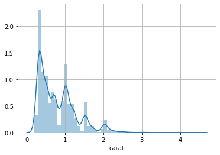

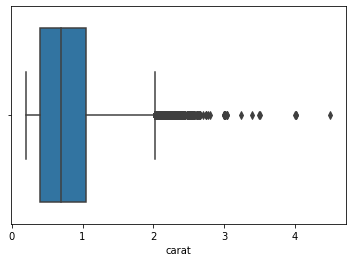

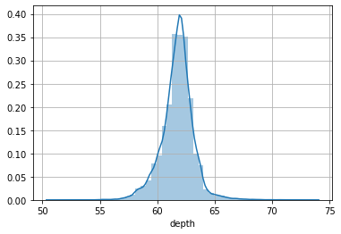

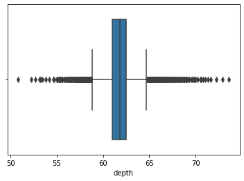

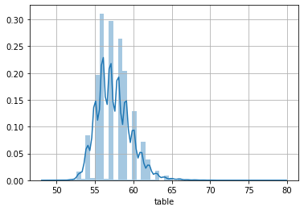

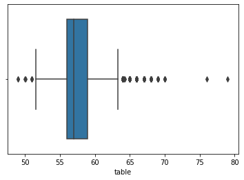

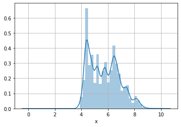

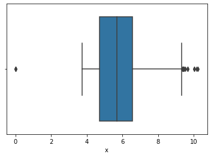

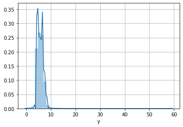

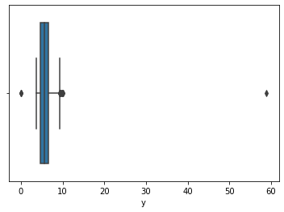

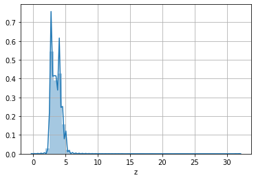

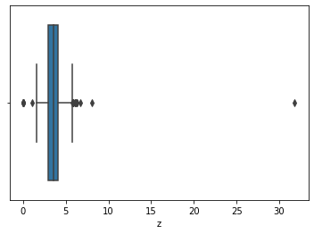

[2 more figures not shown]

```python
cols=['carat' ,'depth', 'table', 'x', 'y', 'z','price']
for i in cols:
    sns.distplot(df[i],hist=True)
    plt.grid()
    plt.show()
    sns.boxplot(df[i])
    plt.show()
```

##### Inference:

Variable like carat,table,X(Length of the cubic zirconia in mm.) ,Y(Width of the cubic zirconia in mm),Z(Height of the cubic zirconia in mm) seems to be positively skewed.

All variables as outliers.

X,Y,Z has value 0 as outliers. So we need to remove zeros while data preprocessing.

Majority of values of carat ranges from 0 to 1.

The depth ranges from 55 to 65 which is normally distributed.

Maximum distribution in table from 55 to 65.

Length(X) ranges from 4 to 8,Width(Y) ranges fro 0 to 10,Height (Z) ranges from 0 to 5.

##### Categorical Variable:

```python
for feature in df.columns:
    if df[feature].dtype == 'object':
        print('feature:',feature)
        counts=df[feature].value_counts()
        print(counts)
        print('\n')
```

```
feature: cut
Ideal        10816
Premium       6899
Very Good     6030
Good          2441
Fair           781
Name: cut, dtype: int64


feature: color
G    5661
E    4917
F    4729
H    4102
D    3344
I    2771
J    1443
Name: color, dtype: int64


feature: clarity
SI1     6571
VS2     6099
SI2     4575
VS1     4093
VVS2    2531
VVS1    1839
IF       894
I1       365
Name: clarity, dtype: int64
```

```
feature: cut
```

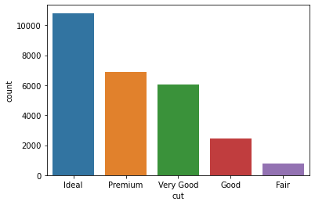

```
feature: color
```

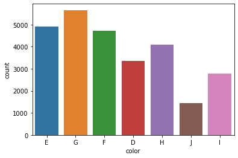

```
feature: clarity
```

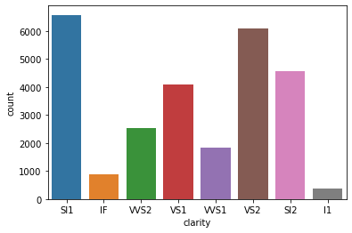

```python
for feature in df.columns:
    if df[feature].dtype == 'object':
        print('feature:',feature)
        sns.countplot(df[feature])
        plt.show()
        print('\n')
```

##### Inferences:

Ideal cut is most preferred cut for diamond.

We have 7 colours in the data, The G seems to be the preferred colour.J is low among other colours.

Sl1 is more prefered clarity for diamond.L1 is less prefered clarity for diamond.

#### Multivariate Analysis:

##### Pair Plot with Contineous Variable:

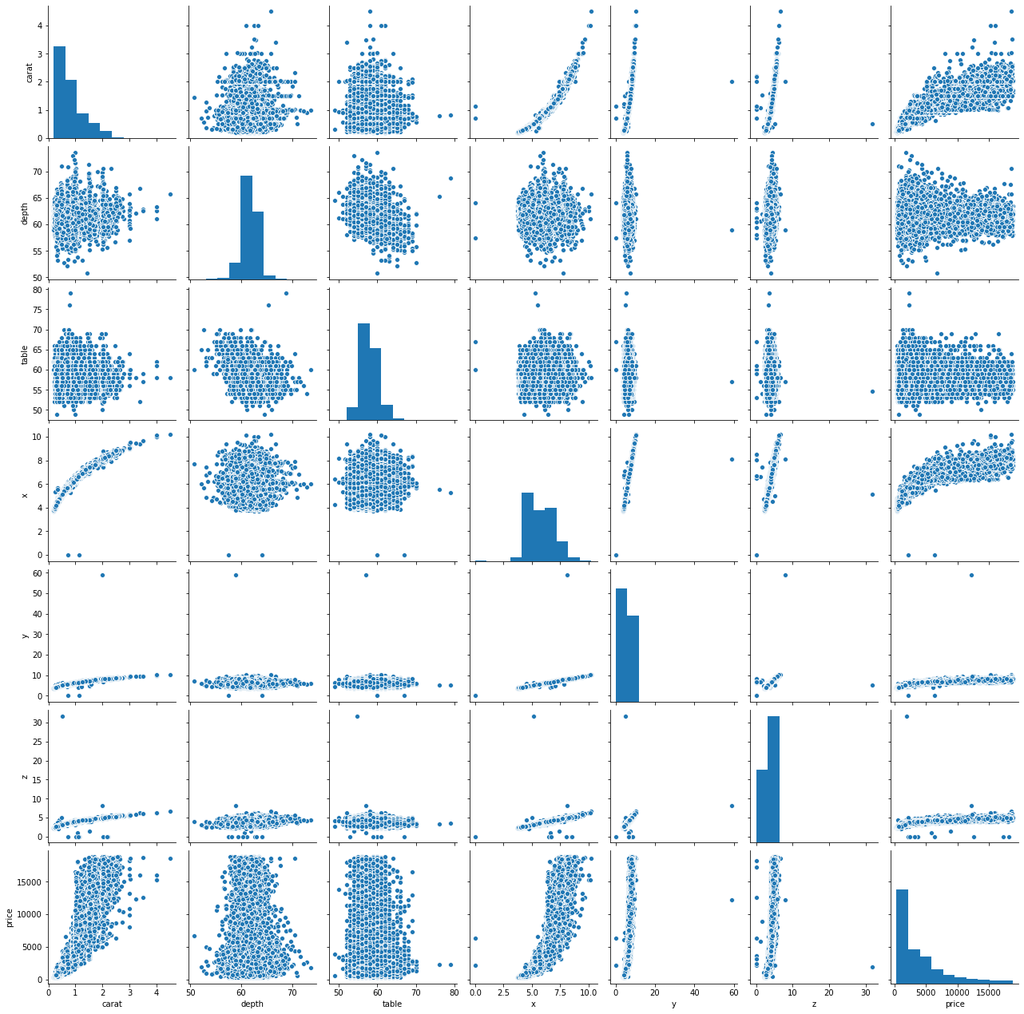

```python
sns.pairplot(df[['carat' ,'depth', 'table', 'x', 'y', 'z','price']],diag_kind='hist')
plt.show()
```

##### Heatmap:

```python
corr = df.corr(method='pearson')
```

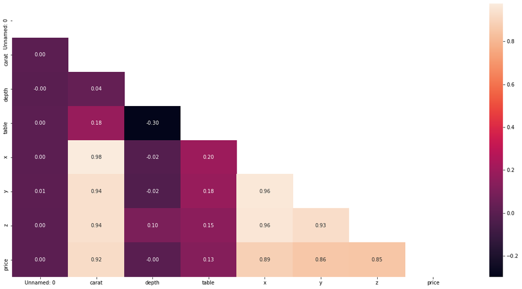

```python
mask = np.triu(np.ones_like(corr, dtype=np.bool))
fig = plt.subplots(figsize=(20, 10))
sns.heatmap(df.corr(), annot=True,fmt='.2f',mask=mask)
plt.show()
```

##### Inference:

Corelation matrix clearly shows there is multicollinearity in the data.

X has good relation with Y,Z and price.

Y has good corelation with Price and Z

Z has good relation with price.

Depth has bad correlation with other variables. which is -0.0 with variable price and -0.02 with variable X & Y.

#### Bivariate Analysis:

##### Cut Vs Price:

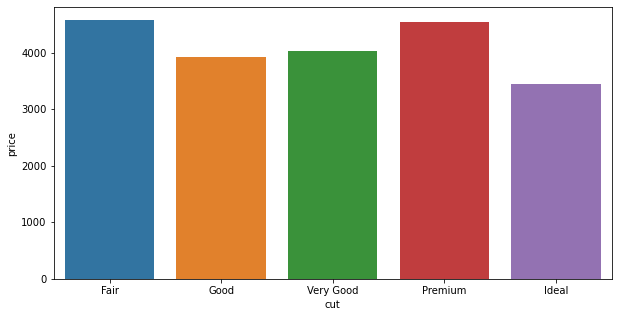

```python
plt.figure(figsize=(10,5))
sns.barplot(x='cut',y='price',data=df,order=['Fair', 'Good', 'Very Good', 'Premium', 'Ideal'],ci=None)
plt.show()
```

##### Inference:

Ideal is nost prefered cut for diamond because price is low compared to other cuts.

Price of fair cut is high so customer shows less interest to buy.

Slight change in price in both Good and Very Good.

Premium price is high but customer is prefered with this cut.

##### Colour Vs Price:

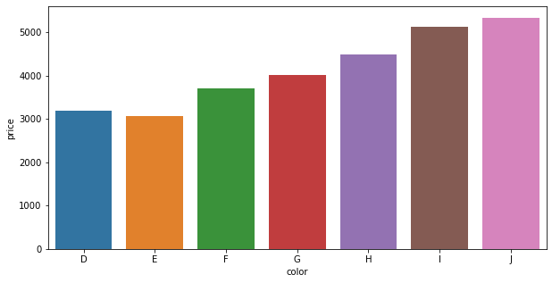

```python
plt.figure(figsize=(10,5))
sns.barplot(x='color',y='price',data=df,ci=None,order = ['D', 'E', 'F', 'G','H', 'I', 'J'])
plt.show()
```

##### Inference:

Price of colour J is high so customer is less prefered with this colour.

Price of colour E is less than colour G but in sales G is good than E.

##### Clarity Vs Price:

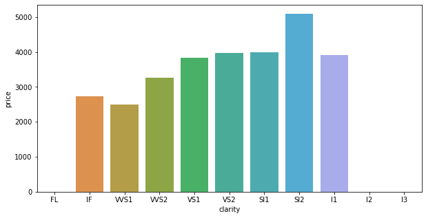

```python
plt.figure(figsize=(10,5))
sns.barplot(x='clarity',y='price',data=df,ci=None,order = ['FL', 'IF', 'VVS1', 'VVS2', 'VS1', 'VS2', 'SI1', 'SI2', 'I1', 'I2', 'I3'])
plt.show()
```

#### Inference:

Sl1 avd Vs2 is cotributing good profit in diamond

Sl2 price is high, So moderate customer preferred this clarity.

Store has no FL,I2 and I3 diamonds.

##### Colour Vs Price With hue Clarity:

```python
pd.crosstab(df['color'], df['clarity'],margins=True)
```

| clarity color | I1 | IF | SI1 | SI2 | VS1 | VS2 | VVS1 | VVS2 | All |
| --- | --- | --- | --- | --- | --- | --- | --- | --- | --- |
| D | 25 | 38 | 1040 | 671 | 369 | 804 | 121 | 276 | 3344 |
| E | 54 | 87 | 1249 | 849 | 625 | 1202 | 342 | 509 | 4917 |
| F | 67 | 183 | 1088 | 753 | 672 | 1107 | 360 | 499 | 4729 |
| G | 68 | 342 | 1001 | 779 | 1078 | 1205 | 507 | 681 | 5661 |
| H | 82 | 149 | 1082 | 796 | 595 | 804 | 288 | 306 | 4102 |
| I | 48 | 69 | 725 | 469 | 480 | 603 | 183 | 194 | 2771 |
| J | 21 | 26 | 386 | 258 | 274 | 374 | 38 | 66 | 1443 |
| All | 365 | 894 | 6571 | 4575 | 4093 | 6099 | 1839 | 2531 | 26967 |

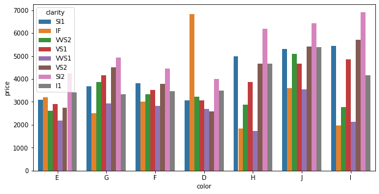

```python
plt.figure(figsize=(10,5))
sns.barplot(x='color',y='price',data=df,hue='clarity',ci=None)
plt.show()
```

##### Colour Vs Price With hue Cut:

```python
pd.crosstab(df['cut'], df['color'],margins=True)
```

| color cut | D | E | F | G | H | I | J | All |
| --- | --- | --- | --- | --- | --- | --- | --- | --- |
| Fair | 74 | 100 | 148 | 147 | 150 | 94 | 68 | 781 |
| Good | 311 | 491 | 454 | 419 | 352 | 253 | 161 | 2441 |
| Ideal | 1409 | 1966 | 1893 | 2470 | 1552 | 1073 | 453 | 10816 |
| Premium | 808 | 1174 | 1167 | 1471 | 1161 | 711 | 407 | 6899 |
| Very Good | 742 | 1186 | 1067 | 1154 | 887 | 640 | 354 | 6030 |
| All | 3344 | 4917 | 4729 | 5661 | 4102 | 2771 | 1443 | 26967 |

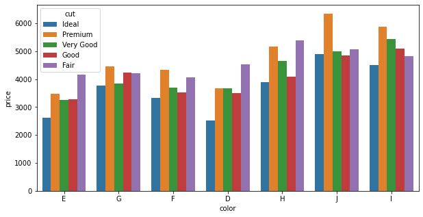

```python
plt.figure(figsize=(10,5))
sns.barplot(x='color',y='price',data=df,hue='cut',ci=None)
plt.show()
```

```python
pd.crosstab(df['cut'], df['clarity'],margins=True)
```

| clarity cut | I1 | IF | SI1 | SI2 | VS1 | VS2 | VVS1 | VVS2 | All |
| --- | --- | --- | --- | --- | --- | --- | --- | --- | --- |
| Fair | 89 | 4 | 193 | 225 | 93 | 129 | 10 | 38 | 781 |
| Good | 51 | 30 | 765 | 530 | 331 | 491 | 100 | 143 | 2441 |
| Ideal | 74 | 613 | 2150 | 1324 | 1784 | 2528 | 1036 | 1307 | 10816 |
| Premium | 108 | 115 | 1809 | 1449 | 998 | 1697 | 307 | 416 | 6899 |
| Very Good | 43 | 132 | 1654 | 1047 | 887 | 1254 | 386 | 627 | 6030 |
| All | 365 | 894 | 6571 | 4575 | 4093 | 6099 | 1839 | 2531 | 26967 |

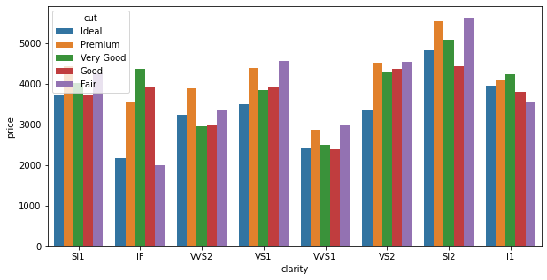

```python
plt.figure(figsize=(10,5))
sns.barplot(x='clarity',y='price',data=df,hue='cut',ci=None)
plt.show()
```

### 1.2 Impute null values if present, also check for the values which are equal to zero. Do they have any meaning or do we need to change them or drop them? Check for the possibility of combining the sub levels of a ordinal variables and take actions accordingly. Explain why you are combining these sub levels with appropriate reasoning

##### Data Preprocessing:

```python
df.isnull().sum()
```

```
Unnamed: 0      0
carat           0
cut             0
color           0
clarity         0
depth         697
table           0
x               0
y               0
z               0
price           0
dtype: int64
```

```python
df[df['x'] == 0]
```

|  | Unnamed: 0 | carat | cut | color | clarity | depth | table | x | y | z | price |
| --- | --- | --- | --- | --- | --- | --- | --- | --- | --- | --- | --- |
| 5821 | 5822 | 0.71 | Good | F | SI2 | 64.1 | 60.0 | 0.0 | 0.0 | 0.0 | 2130 |
| 6215 | 6216 | 0.71 | Good | F | SI2 | 64.1 | 60.0 | 0.0 | 0.0 | 0.0 | 2130 |
| 17506 | 17507 | 1.14 | Fair | G | VS1 | 57.5 | 67.0 | 0.0 | 0.0 | 0.0 | 6381 |

```python
df[df['y'] == 0]
```

|  | Unnamed: 0 | carat | cut | color | clarity | depth | table | x | y | z | price |
| --- | --- | --- | --- | --- | --- | --- | --- | --- | --- | --- | --- |
| 5821 | 5822 | 0.71 | Good | F | SI2 | 64.1 | 60.0 | 0.0 | 0.0 | 0.0 | 2130 |
| 6215 | 6216 | 0.71 | Good | F | SI2 | 64.1 | 60.0 | 0.0 | 0.0 | 0.0 | 2130 |
| 17506 | 17507 | 1.14 | Fair | G | VS1 | 57.5 | 67.0 | 0.0 | 0.0 | 0.0 | 6381 |

```python
df[df['z'] == 0]
```

|  | Unnamed: 0 | carat | cut | color | clarity | depth | table | x | y | z | price |
| --- | --- | --- | --- | --- | --- | --- | --- | --- | --- | --- | --- |
| 5821 | 5822 | 0.71 | Good | F | SI2 | 64.1 | 60.0 | 0.00 | 0.00 | 0.0 | 2130 |
| 6034 | 6035 | 2.02 | Premium | H | VS2 | 62.7 | 53.0 | 8.02 | 7.95 | 0.0 | 18207 |
| 6215 | 6216 | 0.71 | Good | F | SI2 | 64.1 | 60.0 | 0.00 | 0.00 | 0.0 | 2130 |
| 10827 | 10828 | 2.20 | Premium | H | SI1 | 61.2 | 59.0 | 8.42 | 8.37 | 0.0 | 17265 |
| 12498 | 12499 | 2.18 | Premium | H | SI2 | 59.4 | 61.0 | 8.49 | 8.45 | 0.0 | 12631 |
| 12689 | 12690 | 1.10 | Premium | G | SI2 | 63.0 | 59.0 | 6.50 | 6.47 | 0.0 | 3696 |
| 17506 | 17507 | 1.14 | Fair | G | VS1 | 57.5 | 67.0 | 0.00 | 0.00 | 0.0 | 6381 |
| 18194 | 18195 | 1.01 | Premium | H | I1 | 58.1 | 59.0 | 6.66 | 6.60 | 0.0 | 3167 |
| 23758 | 23759 | 1.12 | Premium | G | I1 | 60.4 | 59.0 | 6.71 | 6.67 | 0.0 | 2383 |

```python
df.drop(df[((df['x'] == 0) | (df['y'] == 0) | (df['z'] == 0))].index, inplace=True)
```

```python
for column in df.columns:
    if df[column].dtype != 'object':
        median = df[column].median()
        df[column] = df[column].fillna(median)
```

```python
df.isnull().sum()
```

```
Unnamed: 0    0
carat         0
cut           0
color         0
clarity       0
depth         0
table         0
x             0
y             0
z             0
price         0
dtype: int64
```

##### Inference:

we have Null values in depth, since depth being continuous variable mean or median imputation can be done.

The percentage of Null values is less than 5% (ie) 2.58%, we can also drop these if we want.

After median imputation, we don’t have any null values in the dataset.

X,Y,Z are dimension of diamonds has zeors in data this is unacceptable because dimensions will not be zero's anymore. This will not help to build the model, So we can drop the Zero's which is less in data.

#### Data Scaling:

Standardization of a dataset is a common requirement for many machine learning estimators: they might behave badly if the individual features do not more or less look like standard normally distributed data (e.g. Gaussian with 0 mean and unit variance).

```python
from sklearn.preprocessing import StandardScaler
```

```python
sc = StandardScaler()
```

```python
# get numeric data
num_d = df.select_dtypes(exclude=['object'])

# update the cols with their normalized values
df[num_d.columns] = sc.fit_transform(num_d)
```

```python
num_d.head()
```

|  | Unnamed: 0 | carat | depth | table | x | y | z | price |
| --- | --- | --- | --- | --- | --- | --- | --- | --- |
| 0 | 1 | 0.30 | 62.1 | 58.0 | 4.27 | 4.29 | 2.66 | 499 |
| 1 | 2 | 0.33 | 60.8 | 58.0 | 4.42 | 4.46 | 2.70 | 984 |
| 2 | 3 | 0.90 | 62.2 | 60.0 | 6.04 | 6.12 | 3.78 | 6289 |
| 3 | 4 | 0.42 | 61.6 | 56.0 | 4.82 | 4.80 | 2.96 | 1082 |
| 4 | 5 | 0.31 | 60.4 | 59.0 | 4.35 | 4.43 | 2.65 | 779 |

#### Outlier Teatment:

##### Before Treatment:

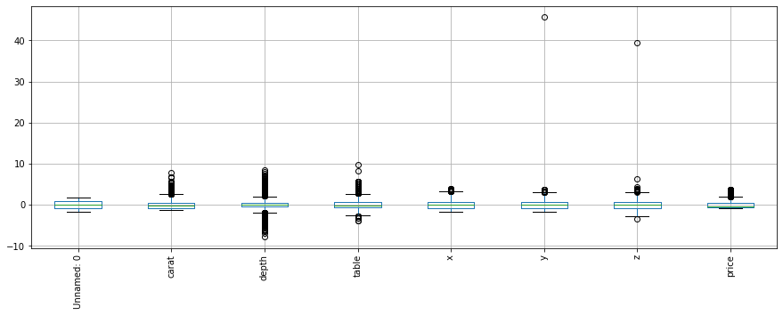

```python
df.boxplot(figsize=(15,5))
plt.xticks(rotation=90)
plt.show()
```

```python
cont=df.dtypes[(df.dtypes!='uint8') & (df.dtypes!='object')].index
```

```python
def remove_outlier(col):
    sorted(col)
    Q1,Q3=np.percentile(col,[25,75])
    IQR=Q3-Q1
    lower_range= Q1-(1.5 * IQR)
    upper_range= Q3+(1.5 * IQR)
    return lower_range, upper_range
```

```python
for column in df[cont].columns:
    lr,ur=remove_outlier(df[column])
    df[column]=np.where(df[column]>ur,ur,df[column])
    df[column]=np.where(df[column]<lr,lr,df[column])
```

##### After Treatment:

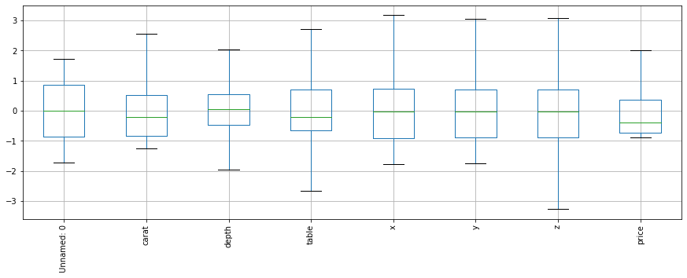

```python
df.boxplot(figsize=(15,5))
plt.xticks(rotation=90)
plt.show()
```

##### Inference:

Linear Regression models are sensitive to Outliers.

Normalisation is used to transform all variables in the data to a same range. It doesn't solve the problem caused by outliers. So, as you can see the after normalisation also, the outliers remains outliers. Only the range is changed.

Removal of outliers creates a normal distribution in some of my variables, and makes transformations for the other variables more effective. Therefore, it seems that removal of outliers before transformation is the better option.

Compare the respective medians of each box plot. If the median line of a box plot lies outside of the box of a comparison box plot, then there is likely to be a difference between the two groups.

### 1.3 Encode the data (having string values) for Modelling. Split the data into train and test (70:30). Apply Linear regression using scikit learn. Perform checks for significant variables using appropriate method from statsmodel. Create multiple models and check the performance of Predictions on Train and Test sets using Rsquare, RMSE & Adj Rsquare. Compare these models and select the best one with appropriate reasoning.

##### Creating get_dumies for categorical Variable:

```python
data = pd.get_dummies(df, columns=['cut','color','clarity'],drop_first=True)
```

```python
data.head()
```

|  | Unnamed: 0 | carat | depth | table | x | y | z | price | cut_Good | cut_Ideal | ... | color_H | color_I | color_J | clarity_IF | clarity_SI1 | clarity_SI2 | clarity_VS1 | clarity_VS2 | clarity_VVS1 | clarity_VVS2 |
| --- | --- | --- | --- | --- | --- | --- | --- | --- | --- | --- | --- | --- | --- | --- | --- | --- | --- | --- | --- | --- | --- |
| 0 | -1.731904 | -1.043125 | 0.253399 | 0.244112 | -1.295920 | -1.240065 | -1.224865 | -0.854851 | 0 | 1 | ... | 0 | 0 | 0 | 0 | 1 | 0 | 0 | 0 | 0 | 0 |
| 1 | -1.731776 | -0.980310 | -0.679158 | 0.244112 | -1.162787 | -1.094057 | -1.169142 | -0.734303 | 0 | 0 | ... | 0 | 0 | 0 | 1 | 0 | 0 | 0 | 0 | 0 | 0 |
| 2 | -1.731647 | 0.213173 | 0.325134 | 1.140496 | 0.275049 | 0.331668 | 0.335404 | 0.584271 | 0 | 0 | ... | 0 | 0 | 0 | 0 | 0 | 0 | 0 | 0 | 0 | 1 |
| 3 | -1.731519 | -0.791865 | -0.105277 | -0.652273 | -0.807766 | -0.802041 | -0.806936 | -0.709945 | 0 | 1 | ... | 0 | 0 | 0 | 0 | 0 | 0 | 1 | 0 | 0 | 0 |
| 4 | -1.731390 | -1.022187 | -0.966099 | 0.692304 | -1.224916 | -1.119823 | -1.238796 | -0.785257 | 0 | 1 | ... | 0 | 0 | 0 | 0 | 0 | 0 | 0 | 0 | 1 | 0 |

5 rows × 25 columns

```python
# drop the id column as it is useless for the model
data_model = data.drop(columns=['Unnamed: 0'], axis=1)
```

```python
# Dropping the target variable
X = data_model.drop('price', axis=1)

# Copy target into the y dataframe.
y = data_model.price
```

```python
X.head()
```

|  | carat | depth | table | x | y | z | cut_Good | cut_Ideal | cut_Premium | cut_Very Good | ... | color_H | color_I | color_J | clarity_IF | clarity_SI1 | clarity_SI2 | clarity_VS1 | clarity_VS2 | clarity_VVS1 | clarity_VVS2 |
| --- | --- | --- | --- | --- | --- | --- | --- | --- | --- | --- | --- | --- | --- | --- | --- | --- | --- | --- | --- | --- | --- |
| 0 | -1.043125 | 0.253399 | 0.244112 | -1.295920 | -1.240065 | -1.224865 | 0 | 1 | 0 | 0 | ... | 0 | 0 | 0 | 0 | 1 | 0 | 0 | 0 | 0 | 0 |
| 1 | -0.980310 | -0.679158 | 0.244112 | -1.162787 | -1.094057 | -1.169142 | 0 | 0 | 1 | 0 | ... | 0 | 0 | 0 | 1 | 0 | 0 | 0 | 0 | 0 | 0 |
| 2 | 0.213173 | 0.325134 | 1.140496 | 0.275049 | 0.331668 | 0.335404 | 0 | 0 | 0 | 1 | ... | 0 | 0 | 0 | 0 | 0 | 0 | 0 | 0 | 0 | 1 |
| 3 | -0.791865 | -0.105277 | -0.652273 | -0.807766 | -0.802041 | -0.806936 | 0 | 1 | 0 | 0 | ... | 0 | 0 | 0 | 0 | 0 | 0 | 1 | 0 | 0 | 0 |
| 4 | -1.022187 | -0.966099 | 0.692304 | -1.224916 | -1.119823 | -1.238796 | 0 | 1 | 0 | 0 | ... | 0 | 0 | 0 | 0 | 0 | 0 | 0 | 0 | 1 | 0 |

5 rows × 23 columns

```python
pd.DataFrame(y.head())
```

|  | price |
| --- | --- |
| 0 | -0.854851 |
| 1 | -0.734303 |
| 2 | 0.584271 |
| 3 | -0.709945 |
| 4 | -0.785257 |

#### Train and Test Split:

```python
# Split X and y into training and test set in 70:30 ratio

X_train, X_test, y_train, y_test = train_test_split(X, y, test_size=0.3 , random_state=1)
```

### Building Linear Regression Model:

Regression analysis is one of the most commonly used toolstofind a relationship (linear or non-linear) between a responseand one or more predictorsand exploit that relationship in predicting the expected value of the response for certain values of the predictor(s) with maximum accuracy possible.

```python
# invoke the LinearRegression function and find the bestfit model on training data

regression_model = LinearRegression()
regression_model.fit(X_train, y_train)
```

```
LinearRegression()
```

```python
# Let us explore the coefficients for each of the independent attributes

for idx, col_name in enumerate(X_train.columns):
    print("The coefficient for {} is {}".format(col_name,regression_model.coef_[idx]))
```

```
The coefficient for carat is 1.1009417847804501
The coefficient for depth is 0.005605143445570377
The coefficient for table is -0.013319500386804035
The coefficient for x is -0.30504349819633475
The coefficient for y is 0.30391448957926553
The coefficient for z is -0.13916571567987943
The coefficient for cut_Good is 0.09403402912977911
The coefficient for cut_Ideal is 0.1523107462056746
The coefficient for cut_Premium is 0.14852774839849378
The coefficient for cut_Very Good is 0.12583881878452705
The coefficient for color_E is -0.04705442233369822
The coefficient for color_F is -0.06268437439142825
The coefficient for color_G is -0.10072161838356786
The coefficient for color_H is -0.20767313311661612
The coefficient for color_I is -0.3239541927462737
The coefficient for color_J is -0.46858930275015803
The coefficient for clarity_IF is 0.9997691394634902
The coefficient for clarity_SI1 is 0.6389785818271332
The coefficient for clarity_SI2 is 0.42959662348315514
The coefficient for clarity_VS1 is 0.8380875826737564
The coefficient for clarity_VS2 is 0.7660244466083613
The coefficient for clarity_VVS1 is 0.9420769630114072
The coefficient for clarity_VVS2 is 0.9313670288415696
```

```python
# Let us check the intercept for the model

intercept = regression_model.intercept_

print("The intercept for our model is {}".format(intercept))
```

```
The intercept for our model is -0.7567627863049391
```

```python
# R square on training data
regression_model.score(X_train, y_train)
```

```
0.9419557931252712
```

```python
# R square on testing data
regression_model.score(X_test, y_test)
```

```
0.9381643998102491
```

```python
#RMSE on Training data
predicted_train=regression_model.fit(X_train, y_train).predict(X_train)
np.sqrt(metrics.mean_squared_error(y_train,predicted_train))
```

```
0.20690072466418796
```

```python
#RMSE on Testing data
predicted_test=regression_model.fit(X_train, y_train).predict(X_test)
np.sqrt(metrics.mean_squared_error(y_test,predicted_test))
```

```
0.21647817772382869
```

```python
data_train = pd.concat([X_train, y_train], axis=1)
data_train.head()
```

|  | carat | depth | table | x | y | z | cut_Good | cut_Ideal | cut_Premium | cut_Very Good | ... | color_I | color_J | clarity_IF | clarity_SI1 | clarity_SI2 | clarity_VS1 | clarity_VS2 | clarity_VVS1 | clarity_VVS2 | price |
| --- | --- | --- | --- | --- | --- | --- | --- | --- | --- | --- | --- | --- | --- | --- | --- | --- | --- | --- | --- | --- | --- |
| 7598 | -0.184654 | 1.114220 | 0.692304 | -0.186479 | -0.106356 | -0.026801 | 0 | 0 | 0 | 1 | ... | 0 | 0 | 0 | 0 | 0 | 1 | 0 | 0 | 0 | -0.290884 |
| 8882 | -1.043125 | 0.827280 | 0.244112 | -1.295920 | -1.222887 | -1.169142 | 0 | 0 | 0 | 1 | ... | 0 | 0 | 0 | 0 | 0 | 0 | 1 | 0 | 0 | -0.843667 |
| 22763 | -0.205593 | 1.544631 | 0.692304 | -0.079973 | -0.114944 | 0.070716 | 1 | 0 | 0 | 0 | ... | 0 | 0 | 0 | 0 | 0 | 0 | 1 | 0 | 0 | -0.394531 |
| 6643 | -0.917495 | -1.109569 | -0.652273 | -0.958650 | -0.956637 | -1.043763 | 0 | 1 | 0 | 0 | ... | 0 | 0 | 0 | 0 | 0 | 0 | 1 | 0 | 0 | -0.710442 |
| 18701 | 1.804485 | 0.899015 | -0.204081 | 1.526498 | 1.516910 | 1.630986 | 0 | 0 | 0 | 1 | ... | 1 | 0 | 0 | 1 | 0 | 0 | 0 | 0 | 0 | 1.233492 |

5 rows × 24 columns

```python
data_train.rename(columns = {'cut_Very Good' : 'cut_Very_Good'}, inplace = True)
```

#### Inferential statistics:

The simple linear regression model involves unknownparameters 𝛽0and 𝛽1,which need to be estimated from data. There are severaldifferent methods of estimating the parameters. The simplest and themost widely used methodis known as the Ordinary Least Squares method (OLS).

```python
import statsmodels.formula.api as smf
lm1 = smf.ols(formula= 'price ~ carat + depth + table + x+ y + z + cut_Good + cut_Ideal + cut_Premium + cut_Very_Good + color_E + color_F + color_G + color_H + color_I + color_J + clarity_IF + clarity_SI1 + clarity_SI2 + clarity_VS1 + clarity_VS2 + clarity_VVS1 + clarity_VVS2', data = data_train).fit()
lm1.params
```

```
Intercept       -0.756763
carat            1.100942
depth            0.005605
table           -0.013320
x               -0.305043
y                0.303914
z               -0.139166
cut_Good         0.094034
cut_Ideal        0.152311
cut_Premium      0.148528
cut_Very_Good    0.125839
color_E         -0.047054
color_F         -0.062684
color_G         -0.100722
color_H         -0.207673
color_I         -0.323954
color_J         -0.468589
clarity_IF       0.999769
clarity_SI1      0.638979
clarity_SI2      0.429597
clarity_VS1      0.838088
clarity_VS2      0.766024
clarity_VVS1     0.942077
clarity_VVS2     0.931367
dtype: float64
```

```python
print(lm1.summary())
```

```
                            OLS Regression Results
==============================================================================
Dep. Variable:                  price   R-squared:                       0.942
Model:                            OLS   Adj. R-squared:                  0.942
Method:                 Least Squares   F-statistic:                 1.330e+04
Date:                Wed, 06 Oct 2021   Prob (F-statistic):               0.00
Time:                        13:58:22   Log-Likelihood:                 2954.6
No. Observations:               18870   AIC:                            -5861.
Df Residuals:                   18846   BIC:                            -5673.
Df Model:                          23
Covariance Type:            nonrobust
=================================================================================
                    coef    std err          t      P>|t|      [0.025      0.975]
---------------------------------------------------------------------------------
Intercept        -0.7568      0.016    -46.999      0.000      -0.788      -0.725
carat             1.1009      0.009    121.892      0.000       1.083       1.119
depth             0.0056      0.004      1.525      0.127      -0.002       0.013
table            -0.0133      0.002     -6.356      0.000      -0.017      -0.009
x                -0.3050      0.032     -9.531      0.000      -0.368      -0.242
y                 0.3039      0.034      8.934      0.000       0.237       0.371
z                -0.1392      0.024     -5.742      0.000      -0.187      -0.092
cut_Good          0.0940      0.011      8.755      0.000       0.073       0.115
cut_Ideal         0.1523      0.010     14.581      0.000       0.132       0.173
cut_Premium       0.1485      0.010     14.785      0.000       0.129       0.168
cut_Very_Good     0.1258      0.010     12.269      0.000       0.106       0.146
color_E          -0.0471      0.006     -8.429      0.000      -0.058      -0.036
color_F          -0.0627      0.006    -11.075      0.000      -0.074      -0.052
color_G          -0.1007      0.006    -18.258      0.000      -0.112      -0.090
color_H          -0.2077      0.006    -35.323      0.000      -0.219      -0.196
color_I          -0.3240      0.007    -49.521      0.000      -0.337      -0.311
color_J          -0.4686      0.008    -58.186      0.000      -0.484      -0.453
clarity_IF        0.9998      0.016     62.524      0.000       0.968       1.031
clarity_SI1       0.6390      0.014     46.643      0.000       0.612       0.666
clarity_SI2       0.4296      0.014     31.177      0.000       0.403       0.457
clarity_VS1       0.8381      0.014     59.986      0.000       0.811       0.865
clarity_VS2       0.7660      0.014     55.618      0.000       0.739       0.793
clarity_VVS1      0.9421      0.015     63.630      0.000       0.913       0.971
clarity_VVS2      0.9314      0.014     64.730      0.000       0.903       0.960
==============================================================================
Omnibus:                     4696.785   Durbin-Watson:                   1.994
Prob(Omnibus):                  0.000   Jarque-Bera (JB):            17654.853
Skew:                           1.208   Prob(JB):                         0.00
Kurtosis:                       7.076   Cond. No.                         57.0
==============================================================================

Notes:
[1] Standard Errors assume that the covariance matrix of the errors is correctly specified.
```

##### Inference:

However, the numerical value of R squre is non-decreasing even if non-significant predictors are included in the model. Addition of non-significant predictors adversely affect the predictive quality of the model. Therefore, there is a need of another measure of model adequacy.

𝑅 squre measures the proportion of the total variation in𝑌that is explained by the regression model. It ranges from 0≤𝑅^2≤1.The higher the value of 𝑅2,the more powerful is the predictor to predict the response.Aregression model with high 𝑅2value indicates that the model fits the data well. In that case a high proportion of variance in the response is explained by the dependence of the response on the predictor.

```python
# Let us check the sum of squared errors by predicting value of y for test cases and
# subtracting from the actual y for the test cases

mse = np.mean((regression_model.predict(X_test)-y_test)**2)
```

```python
# underroot of mean_sq_error is standard deviation i.e. avg variance between predicted and actual

import math

math.sqrt(mse)
```

```
0.21647817772382863
```

```python
# Model score - R2 or coeff of determinant
# R^2=1–RSS / TSS

regression_model.score(X_test, y_test)
```

```
0.9381643998102491
```

```python
# predict mileage (mpg) for a set of attributes not in the training or test set
y_pred = regression_model.predict(X_test)
```

```python
import statsmodels.formula.api as smf
lm2 = smf.ols(formula= 'price ~ carat  + table  + x + y + z + cut_Good + cut_Ideal + cut_Premium + cut_Very_Good + color_E + color_F + color_G + color_H + color_I + color_J + clarity_IF + clarity_SI1 + clarity_SI2 + clarity_VS1 + clarity_VS2 + clarity_VVS1 + clarity_VVS2', data = data_train).fit()
lm2.params
```

```
Intercept       -0.756657
carat            1.101954
table           -0.013928
x               -0.315617
y                0.283420
z               -0.108789
cut_Good         0.095123
cut_Ideal        0.151173
cut_Premium      0.147355
cut_Very_Good    0.125514
color_E         -0.047114
color_F         -0.062727
color_G         -0.100657
color_H         -0.207568
color_I         -0.323689
color_J         -0.468428
clarity_IF       1.000046
clarity_SI1      0.639804
clarity_SI2      0.430195
clarity_VS1      0.838626
clarity_VS2      0.766683
clarity_VVS1     0.942390
clarity_VVS2     0.931898
dtype: float64
```

```python
print(lm2.summary())
```

```
                            OLS Regression Results
==============================================================================
Dep. Variable:                  price   R-squared:                       0.942
Model:                            OLS   Adj. R-squared:                  0.942
Method:                 Least Squares   F-statistic:                 1.390e+04
Date:                Wed, 06 Oct 2021   Prob (F-statistic):               0.00
Time:                        13:58:22   Log-Likelihood:                 2953.5
No. Observations:               18870   AIC:                            -5861.
Df Residuals:                   18847   BIC:                            -5680.
Df Model:                          22
Covariance Type:            nonrobust
=================================================================================
                    coef    std err          t      P>|t|      [0.025      0.975]
---------------------------------------------------------------------------------
Intercept        -0.7567      0.016    -46.991      0.000      -0.788      -0.725
carat             1.1020      0.009    122.331      0.000       1.084       1.120
table            -0.0139      0.002     -6.770      0.000      -0.018      -0.010
x                -0.3156      0.031    -10.101      0.000      -0.377      -0.254
y                 0.2834      0.031      9.069      0.000       0.222       0.345
z                -0.1088      0.014     -7.883      0.000      -0.136      -0.082
cut_Good          0.0951      0.011      8.876      0.000       0.074       0.116
cut_Ideal         0.1512      0.010     14.508      0.000       0.131       0.172
cut_Premium       0.1474      0.010     14.711      0.000       0.128       0.167
cut_Very_Good     0.1255      0.010     12.239      0.000       0.105       0.146
color_E          -0.0471      0.006     -8.439      0.000      -0.058      -0.036
color_F          -0.0627      0.006    -11.082      0.000      -0.074      -0.052
color_G          -0.1007      0.006    -18.246      0.000      -0.111      -0.090
color_H          -0.2076      0.006    -35.306      0.000      -0.219      -0.196
color_I          -0.3237      0.007    -49.497      0.000      -0.337      -0.311
color_J          -0.4684      0.008    -58.169      0.000      -0.484      -0.453
clarity_IF        1.0000      0.016     62.544      0.000       0.969       1.031
clarity_SI1       0.6398      0.014     46.738      0.000       0.613       0.667
clarity_SI2       0.4302      0.014     31.232      0.000       0.403       0.457
clarity_VS1       0.8386      0.014     60.042      0.000       0.811       0.866
clarity_VS2       0.7667      0.014     55.691      0.000       0.740       0.794
clarity_VVS1      0.9424      0.015     63.655      0.000       0.913       0.971
clarity_VVS2      0.9319      0.014     64.784      0.000       0.904       0.960
==============================================================================
Omnibus:                     4699.504   Durbin-Watson:                   1.994
Prob(Omnibus):                  0.000   Jarque-Bera (JB):            17704.272
Skew:                           1.208   Prob(JB):                         0.00
Kurtosis:                       7.084   Cond. No.                         56.5
==============================================================================

Notes:
[1] Standard Errors assume that the covariance matrix of the errors is correctly specified.
```

##### Inference:

Notice that now, all the predictors are statistically significant with very low p-values. The value of R squre has not decreased much and adjusted R squres almost same as R squre(around 94%). Thus we select this as our final regression model.

```python
# concatenate X and y into a single dataframe
data_train = pd.concat([X_train, y_train], axis=1)
data_test=pd.concat([X_test,y_test],axis=1)
data_train.head()
```

|  | carat | depth | table | x | y | z | cut_Good | cut_Ideal | cut_Premium | cut_Very Good | ... | color_I | color_J | clarity_IF | clarity_SI1 | clarity_SI2 | clarity_VS1 | clarity_VS2 | clarity_VVS1 | clarity_VVS2 | price |
| --- | --- | --- | --- | --- | --- | --- | --- | --- | --- | --- | --- | --- | --- | --- | --- | --- | --- | --- | --- | --- | --- |
| 7598 | -0.184654 | 1.114220 | 0.692304 | -0.186479 | -0.106356 | -0.026801 | 0 | 0 | 0 | 1 | ... | 0 | 0 | 0 | 0 | 0 | 1 | 0 | 0 | 0 | -0.290884 |
| 8882 | -1.043125 | 0.827280 | 0.244112 | -1.295920 | -1.222887 | -1.169142 | 0 | 0 | 0 | 1 | ... | 0 | 0 | 0 | 0 | 0 | 0 | 1 | 0 | 0 | -0.843667 |
| 22763 | -0.205593 | 1.544631 | 0.692304 | -0.079973 | -0.114944 | 0.070716 | 1 | 0 | 0 | 0 | ... | 0 | 0 | 0 | 0 | 0 | 0 | 1 | 0 | 0 | -0.394531 |
| 6643 | -0.917495 | -1.109569 | -0.652273 | -0.958650 | -0.956637 | -1.043763 | 0 | 1 | 0 | 0 | ... | 0 | 0 | 0 | 0 | 0 | 0 | 1 | 0 | 0 | -0.710442 |
| 18701 | 1.804485 | 0.899015 | -0.204081 | 1.526498 | 1.516910 | 1.630986 | 0 | 0 | 0 | 1 | ... | 1 | 0 | 0 | 1 | 0 | 0 | 0 | 0 | 0 | 1.233492 |

5 rows × 24 columns

```python
data_test.head()
```

|  | carat | depth | table | x | y | z | cut_Good | cut_Ideal | cut_Premium | cut_Very Good | ... | color_I | color_J | clarity_IF | clarity_SI1 | clarity_SI2 | clarity_VS1 | clarity_VS2 | clarity_VVS1 | clarity_VVS2 | price |
| --- | --- | --- | --- | --- | --- | --- | --- | --- | --- | --- | --- | --- | --- | --- | --- | --- | --- | --- | --- | --- | --- |
| 26809 | 0.443495 | 0.109928 | -0.204081 | 0.559065 | 0.580741 | 0.572231 | 0 | 0 | 0 | 1 | ... | 0 | 0 | 0 | 1 | 0 | 0 | 0 | 0 | 0 | 0.122708 |
| 10087 | 0.024729 | 0.038193 | -1.100465 | 0.212920 | 0.254370 | 0.237888 | 0 | 1 | 0 | 0 | ... | 0 | 0 | 0 | 0 | 0 | 1 | 0 | 0 | 0 | 0.082442 |
| 22817 | -0.812804 | 0.181664 | -0.652273 | -0.852144 | -0.793452 | -0.793005 | 0 | 0 | 0 | 1 | ... | 0 | 0 | 0 | 0 | 0 | 0 | 0 | 1 | 0 | -0.689067 |
| 21676 | 0.045667 | 0.396869 | -0.652273 | 0.204044 | 0.245781 | 0.265750 | 0 | 1 | 0 | 0 | ... | 0 | 0 | 0 | 0 | 1 | 0 | 0 | 0 | 0 | -0.272740 |
| 14846 | 0.694754 | 0.683810 | -0.204081 | 0.816456 | 0.812636 | 0.892644 | 0 | 1 | 0 | 0 | ... | 0 | 0 | 0 | 0 | 0 | 0 | 1 | 0 | 0 | 0.642930 |

5 rows × 24 columns

```python
for i,j in np.array(lm2.params.reset_index()):
    print('({}) * {} +'.format(round(j,2),i),end=' ')
```

[output not shown]

### 1.4 Inference: Basis on these predictions, what are the business insights and recommendations.

We had a business problem to predict the price of the stone and provide insights for the company on the profits on different prize slots

we can clearly observe that Carat has the highest coefficient . However Carat value increase the price also increase significantly when compared to any other feature in the data.

Ideal cut is most preferred cut for diamond.

We have 7 colors in the data, The G seems to be the preferred color.J is low among other colors.

For better accuracy dropping depth column in iteration for better results.